# R Notebook

### Atribúty team_id.home a team_id.away

**charakteristika:** Identifikačné číslo NHL tímu v rámci datasetu.

Aktuálne sa v NHL nachádza 31 tímov, pričom sa tento počet od sezóny 2015/2016 nezmenil. Overíme, či sa v datatsete sedí počet tímov a pozrieme sa aj na počet hier každého tímu, ktorý sa môže meniť pri účasti vo vyraďovacej fáze.

```r
length(table(df$team_id.home))
```

```
[1] 34
```

```r
table(df$team_id.home)
```

```
  1   2   3   4   5   6   7   8   9  10  12  13  14  15  16  17  18  19  20  21  22  23  24  25
200 218 209 213 236 228 199 209 211 210 208 204 233 232 208 203 228 232 207 214 206 207 218 223
 26  28  29  30  52  53  54  87  89  90
203 231 214 209 216 201 147   2   2   1
```

```
longer object length is not a multiple of shorter object lengthlonger object length is not a multiple of shorter object length
```

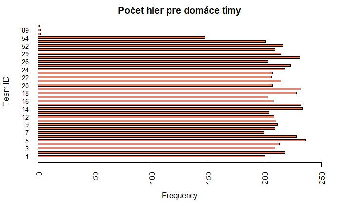

```r
barplot(table(df$team_id.home), las=2, cex.names=.8, xlab="Frequency", ylab="Team ID", main="Počet hier pre domáce tímy", horiz=TRUE, xlim=c(0,250), space=c(1,1,1,1), col=c("salmon2"))
```

```r
table(df$team_id.away)
```

```
  1   2   3   4   5   6   7   8   9  10  12  13  14  15  16  17  18  19  20  21  22  23  24  25
202 219 210 212 232 225 198 206 208 214 211 203 228 233 211 201 231 233 211 217 210 207 212 227
 26  28  29  30  52  53  54  87  88  90
205 229 215 208 212 206 141   1   3   1
```

```
longer object length is not a multiple of shorter object lengthlonger object length is not a multiple of shorter object length
```

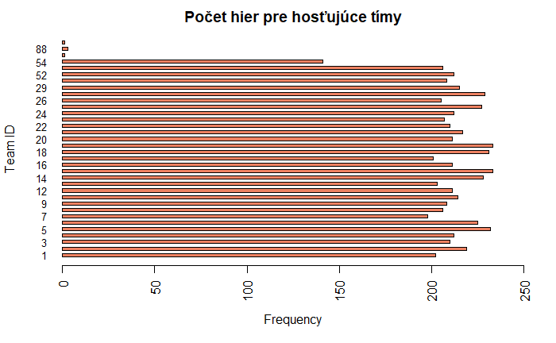

```r
barplot(table(df$team_id.away), las=2, cex.names=.8, xlab="Frequency", ylab="Team ID", main="Počet hier pre hosťujúce tímy", horiz=TRUE, xlim=c(0,250), space=c(1,1,1,1), col=c("salmon2"))
```

```r
df[df$team_id.away >= 55]
```

| season | type | goals.away | goals.home | team_id.away | won.away | shots.away | hits.away | pim.away | powerPlayOpportunities.away | powerPlayGoals.away | faceOffWinPercentage.away | giveaways.away | takeaways.away | blocked.away | abbreviation.away | team_id.home | won.home | settled_in | shots.home | hits.home | pim.home | powerPlayOpportunities.home | powerPlayGoals.home | faceOffWinPercentage.home | giveaways.home | takeaways.home | blocked.home | abbreviation.home | save_percentage.home | … |
| --- | --- | --- | --- | --- | --- | --- | --- | --- | --- | --- | --- | --- | --- | --- | --- | --- | --- | --- | --- | --- | --- | --- | --- | --- | --- | --- | --- | --- | --- | --- |
| 20192020 | A | 5 | 9 | 88 | FALSE | 16 | 0 | 0 | 0 | 0 | 76.2 | 0 | 2 | 1 | NA | 87 | TRUE | tbc | 22 | 1 | 0 | 0 | 0 | 23.8 | 1 | 4 | 0 | NA | 0.6875 | … |
| 20192020 | A | 10 | 5 | 90 | TRUE | 28 | 0 | 0 | 0 | 0 | 35.0 | 1 | 6 | 1 | NA | 89 | FALSE | tbc | 17 | 0 | 0 | 0 | 0 | 65.0 | 1 | 8 | 1 | NA | 0.6429 | … |
| 20192020 | A | 4 | 5 | 87 | FALSE | 11 | 0 | 0 | 0 | 0 | 37.5 | 2 | 5 | 2 | NA | 90 | TRUE | tbc | 20 | 0 | 0 | 0 | 0 | 62.5 | 1 | 6 | 2 | NA | 0.6364 | … |
| 20182019 | A | 7 | 4 | 88 | TRUE | 26 | 0 | 0 | 0 | 0 | 56.2 | 2 | 6 | 1 | NA | 87 | FALSE | tbc | 20 | 0 | 0 | 0 | 0 | 43.8 | 1 | 8 | 0 | NA | 0.7308 | … |
| 20182019 | A | 10 | 5 | 88 | TRUE | 22 | 0 | 0 | 0 | 0 | 45.0 | 3 | 5 | 1 | NA | 89 | FALSE | tbc | 23 | 0 | 0 | 0 | 0 | 55.0 | 4 | 4 | 2 | NA | 0.5455 | … |

Z výpisu môžeme vidieť, že tímy s nízkym počtom zápasov sú exhibičné tímy, ktoré sme úvadzali vyššie - nejedná sa o tímy NHL. Tieto záznamy teda bude potrebné odstrániť.

### Atribúty won.home a won.away

**charakteristika:** jedná sa o boolean atribúty, vyjadrujú ktorý tím v zápase zvíťazil. V drtivej väčšine prípadov sú opačné, t.j TRUE FALSE alebo FALSE TRUE. Môže však nastať aj situácia v ktorej majú oba hodnotu FALSE - keďže remízy v týchto sezónach neboli povolené, tieto hodnoty by sa reálne v datasete vyskytovať pri legitímnych záznamoch nemali.

```r
unique(df$won.home)
```

```
[1]  TRUE FALSE
```

```r
unique(df$won.away)
```

```
[1] FALSE  TRUE
```

```r
subset(df, won.home==TRUE & won.away==TRUE)
```

| season | type | goals.away | goals.home | team_id.away | won.away | shots.away | hits.away | pim.away | powerPlayOpportunities.away | powerPlayGoals.away | faceOffWinPercentage.away | giveaways.away | takeaways.away | blocked.away | abbreviation.away | team_id.home | won.home | settled_in | shots.home | hits.home | pim.home | powerPlayOpportunities.home | powerPlayGoals.home | faceOffWinPercentage.home | giveaways.home | takeaways.home | blocked.home | abbreviation.home | save_percentage.home | … |
| --- | --- | --- | --- | --- | --- | --- | --- | --- | --- | --- | --- | --- | --- | --- | --- | --- | --- | --- | --- | --- | --- | --- | --- | --- | --- | --- | --- | --- | --- | --- |

```r
subset(df, won.home==FALSE & won.away==FALSE)
```

| season | type | goals.away | goals.home | team_id.away | won.away | shots.away | hits.away | pim.away | powerPlayOpportunities.away | powerPlayGoals.away | faceOffWinPercentage.away | giveaways.away | takeaways.away | blocked.away | abbreviation.away | team_id.home | won.home | settled_in | shots.home | hits.home | pim.home | powerPlayOpportunities.home | powerPlayGoals.home | faceOffWinPercentage.home | giveaways.home | takeaways.home | blocked.home | abbreviation.home | save_percentage.home | … |
| --- | --- | --- | --- | --- | --- | --- | --- | --- | --- | --- | --- | --- | --- | --- | --- | --- | --- | --- | --- | --- | --- | --- | --- | --- | --- | --- | --- | --- | --- | --- |
| 20172018 | P | 0 | 0 | 28 | FALSE | 0 | 0 | 0 | 0 | 0 | 0 | 0 | 0 | 0 | SJS | 54 | FALSE | tbc | 0 | 0 | 0 | 0 | 0 | 0 | 0 | 0 | 0 | VGK | NaN | … |
| 20172018 | P | 0 | 0 | 28 | FALSE | NA | NA | NA | NA | NA | NA | NA | NA | NA | SJS | 24 | FALSE | tbc | NA | NA | NA | NA | NA | NA | NA | NA | NA | ANA | NA | … |
| 20172018 | P | 0 | 0 | 26 | FALSE | 0 | 0 | 0 | 0 | 0 | 0 | 0 | 0 | 0 | LAK | 54 | FALSE | tbc | 0 | 0 | 0 | 0 | 0 | 0 | 0 | 0 | 0 | VGK | NaN | … |
| 20172018 | P | 0 | 0 | 52 | FALSE | NA | NA | NA | NA | NA | NA | NA | NA | NA | WPG | 54 | FALSE | tbc | NA | NA | NA | NA | NA | NA | NA | NA | NA | VGK | NA | … |
| 20172018 | P | 0 | 0 | 54 | FALSE | NA | NA | NA | NA | NA | NA | NA | NA | NA | VGK | 52 | FALSE | tbc | NA | NA | NA | NA | NA | NA | NA | NA | NA | WPG | NA | … |
| 20172018 | P | 0 | 0 | 54 | FALSE | 0 | 0 | 0 | 0 | 0 | 0 | 0 | 0 | 0 | VGK | 15 | FALSE | tbc | 0 | 0 | 0 | 0 | 0 | 0 | 0 | 0 | 0 | WSH | NaN | … |
| 20172018 | P | 0 | 0 | 15 | FALSE | 0 | 0 | 0 | 0 | 0 | 0 | 0 | 0 | 0 | WSH | 54 | FALSE | tbc | 0 | 0 | 0 | 0 | 0 | 0 | 0 | 0 | 0 | VGK | NaN | … |
| 20172018 | P | 0 | 0 | 5 | FALSE | 0 | 0 | 0 | 0 | 0 | 0 | 0 | 0 | 0 | PIT | 15 | FALSE | tbc | 0 | 0 | 0 | 0 | 0 | 0 | 0 | 0 | 0 | WSH | NaN | … |
| 20162017 | P | 0 | 0 | 20 | FALSE | 0 | 0 | 0 | 0 | 0 | 0 | 0 | 0 | 0 | CGY | 24 | FALSE | tbc | 0 | 0 | 0 | 0 | 0 | 0 | 0 | 0 | 0 | ANA | NaN | … |
| 20162017 | P | 0 | 0 | 10 | FALSE | 0 | 0 | 0 | 0 | 0 | 0 | 0 | 0 | 0 | TOR | 15 | FALSE | tbc | 0 | 0 | 0 | 0 | 0 | 0 | 0 | 0 | 0 | WSH | NaN | … |

[output cut: 4 more lines]

```r
verify <- subset(df, won.home==FALSE & won.away==FALSE)
```

Výsledok zápasu TRUE TRUE nie je možný. Preto je potrebné skontrolovať, či sa v datasete tento výsledok nenachádza (ak áno je potrebné ho opraviť). Po kontrole s vysužitím funkcie unique sme zistili, že TRUE TRUE sa v datasete nachádza 0x. FALSE FALSE sa vŠak v datasete nachádza 14x - po pohľade na dáta vieme povedať, že sa nebude jednať o remízy - pre záznamy chýbajú dáta, pravdepodobne sa bude jednať o odložené alebo zrušené zápasy. Žiaden z týchto zápasov však pre naše riešenie nemá pridanú hodnotu - keďže chýbajú všetky relevantné štatistické atribúty (resp. ich hodnota je 0), tieto zápasy môžeme úplne bez problémov z datasetu pri čistení odstrániť - nestratíme totižto žiadnu štatisticky cennú informáciu.

```r
unique(verify$season)
```

```
[1] 20172018 20162017
```

```r
table(is.na(df$won.home))
```

```
FALSE
 6582
```

```r
table(is.na(df$won.away))
```

```
FALSE
 6582
```

Atribúty won.home a won.away neobsahujú žiadne prázdne hodnoty, preto nie je potrebné voliť stratégie ich nahrádzania.

### Atribúty shots.home a shots.away

**charakteristika:** atribút reprezentuje počet striel na bránu z pohľadu domáceho a hosťovského tímu.

Pri atribútoch overíme, či neobsahujú chýbajúce hodnoty:

```r
cat("Počet záznamov kde je shots.home NA", nrow(subset(df, is.na(shots.home)==TRUE)), '\n')
```

```
Počet záznamov kde je shots.home NA 4
```

```r
cat("Počet záznamov kde je shots.away NA",nrow(subset(df, is.na(shots.away)==TRUE)),'\n')
```

```
Počet záznamov kde je shots.away NA 4
```

Vidíme, že v štyroch záznamoch nadobúdajú atribúty shots.home a shots.away hodnotu NA. Na tieto záznamy sa môžeme bližšie pozrieť.

```r
subset(df, is.na(shots.home)==TRUE)
```

| season | type | goals.away | goals.home | team_id.away | won.away | shots.away | hits.away | pim.away | powerPlayOpportunities.away | powerPlayGoals.away | faceOffWinPercentage.away | giveaways.away | takeaways.away | blocked.away | abbreviation.away | team_id.home | won.home | settled_in | shots.home | hits.home | pim.home | powerPlayOpportunities.home | powerPlayGoals.home | faceOffWinPercentage.home | giveaways.home | takeaways.home | blocked.home | abbreviation.home | save_percentage.home | … |
| --- | --- | --- | --- | --- | --- | --- | --- | --- | --- | --- | --- | --- | --- | --- | --- | --- | --- | --- | --- | --- | --- | --- | --- | --- | --- | --- | --- | --- | --- | --- |
| 20172018 | P | 0 | 0 | 28 | FALSE | NA | NA | NA | NA | NA | NA | NA | NA | NA | SJS | 24 | FALSE | tbc | NA | NA | NA | NA | NA | NA | NA | NA | NA | ANA | NA | … |
| 20172018 | P | 0 | 0 | 52 | FALSE | NA | NA | NA | NA | NA | NA | NA | NA | NA | WPG | 54 | FALSE | tbc | NA | NA | NA | NA | NA | NA | NA | NA | NA | VGK | NA | … |
| 20172018 | P | 0 | 0 | 54 | FALSE | NA | NA | NA | NA | NA | NA | NA | NA | NA | VGK | 52 | FALSE | tbc | NA | NA | NA | NA | NA | NA | NA | NA | NA | WPG | NA | … |
| 20162017 | P | 0 | 0 | 3 | FALSE | NA | NA | NA | NA | NA | NA | NA | NA | NA | NYR | 9 | FALSE | tbc | NA | NA | NA | NA | NA | NA | NA | NA | NA | OTT | NA | … |

```r
subset(df, is.na(shots.away)==TRUE)
```

| season | type | goals.away | goals.home | team_id.away | won.away | shots.away | hits.away | pim.away | powerPlayOpportunities.away | powerPlayGoals.away | faceOffWinPercentage.away | giveaways.away | takeaways.away | blocked.away | abbreviation.away | team_id.home | won.home | settled_in | shots.home | hits.home | pim.home | powerPlayOpportunities.home | powerPlayGoals.home | faceOffWinPercentage.home | giveaways.home | takeaways.home | blocked.home | abbreviation.home | save_percentage.home | … |
| --- | --- | --- | --- | --- | --- | --- | --- | --- | --- | --- | --- | --- | --- | --- | --- | --- | --- | --- | --- | --- | --- | --- | --- | --- | --- | --- | --- | --- | --- | --- |
| 20172018 | P | 0 | 0 | 28 | FALSE | NA | NA | NA | NA | NA | NA | NA | NA | NA | SJS | 24 | FALSE | tbc | NA | NA | NA | NA | NA | NA | NA | NA | NA | ANA | NA | … |
| 20172018 | P | 0 | 0 | 52 | FALSE | NA | NA | NA | NA | NA | NA | NA | NA | NA | WPG | 54 | FALSE | tbc | NA | NA | NA | NA | NA | NA | NA | NA | NA | VGK | NA | … |
| 20172018 | P | 0 | 0 | 54 | FALSE | NA | NA | NA | NA | NA | NA | NA | NA | NA | VGK | 52 | FALSE | tbc | NA | NA | NA | NA | NA | NA | NA | NA | NA | WPG | NA | … |
| 20162017 | P | 0 | 0 | 3 | FALSE | NA | NA | NA | NA | NA | NA | NA | NA | NA | NYR | 9 | FALSE | tbc | NA | NA | NA | NA | NA | NA | NA | NA | NA | OTT | NA | … |

Z výpisu vidíme, že v oboch prípadoch sa jedná o zápasy play-off medzi tímami NHL, ktoré vŠak neobsahujú žiade štatistické informácie (takmer všetko je NA) - tieto záznamy bude vhodné odstrániť, keďže neobsahujú žiadne relevantné informácie, pravdepodobne sa jedná o zrušené zápasy v play-off. Taktiež je vhodné podotknúť, že tieto 4 zápasy sú rovnaké pre oba atribúty, t.j. po ich odstránení budú odstránené NA hodnoty pre oba atribúty - bude riešené vo fázi čistenia dát.

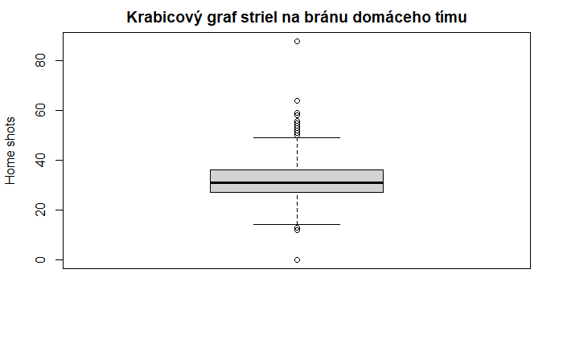

```r
boxplot(df$shots.home, ylab="Home shots", xlab="", main="Krabicový graf striel na bránu domáceho tímu")
```

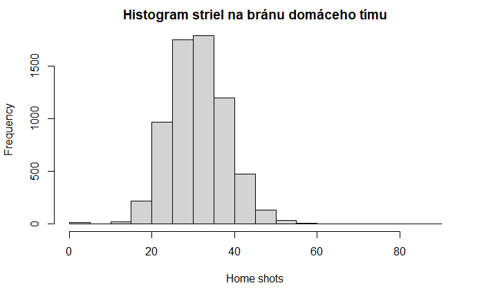

```r
hist(df$shots.home, xlab="Home shots", main="Histogram striel na bránu domáceho tímu")
```

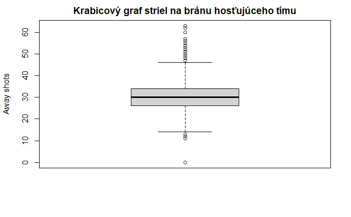

```r
boxplot(df$shots.away, ylab="Away shots", xlab="", main="Krabicový graf striel na bránu hosťujúceho tímu")
```

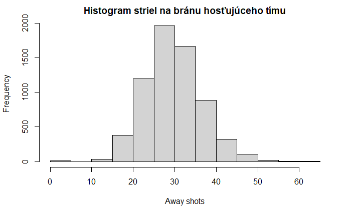

```r
hist(df$shots.away, xlab="Away shots", main="Histogram striel na bránu hosťujúceho tímu")
```

```r
subset(df, df$shots.home >= 80)
```

| season | type | goals.away | goals.home | team_id.away | won.away | shots.away | hits.away | pim.away | powerPlayOpportunities.away | powerPlayGoals.away | faceOffWinPercentage.away | giveaways.away | takeaways.away | blocked.away | abbreviation.away | team_id.home | won.home | settled_in | shots.home | hits.home | pim.home | powerPlayOpportunities.home | powerPlayGoals.home | faceOffWinPercentage.home | giveaways.home | takeaways.home | blocked.home | abbreviation.home | save_percentage.home | … |
| --- | --- | --- | --- | --- | --- | --- | --- | --- | --- | --- | --- | --- | --- | --- | --- | --- | --- | --- | --- | --- | --- | --- | --- | --- | --- | --- | --- | --- | --- | --- |
| 20192020 | P | 2 | 3 | 29 | FALSE | 63 | 46 | 8 | 5 | 1 | 47.8 | 21 | 18 | 62 | CBJ | 14 | TRUE | OT | 88 | 59 | 10 | 4 | 0 | 52.2 | 28 | 13 | 30 | TBL | 0.9683 | … |

Z výpisu záznamu vidíme, že sa jedná o zápas play-off medzi Columbus Blue Jackets a Tamba Bay Lightning, kedy bol počet striel na jednej strane 88 a na druhej 63. Zápas bol taktiež ukončený v predĺžení - keďže v play-off je možný nekonečný počet predĺžení až pokiaľ nie je jasný výsledok zápasu (remíza vo vyraďovacích zápasoch nie je povolená) môžeme predpokladať, že sa jedná o zápas ktorý bol predĺžovaný viac krát. Počty striel sú teda legitímne a nejedná sa o chyby merania. Jedná sa však o veľmi unikátnu situáciu, ktorá môže potenciálne negatívne ovplyvniť výsledky predikčného modelu. Z tohoto dôvôdu je vhodné uvažovať nad normovaním tejto hodnoty.

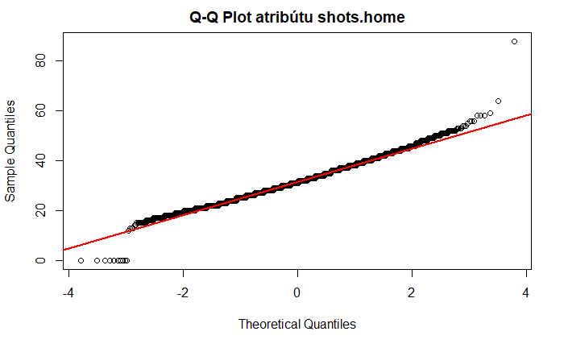

```r
qqnorm(df$shots.home, main="Q-Q Plot atribútu shots.home")
qqline(df$shots.home, col = "red", lwd = 2)
```

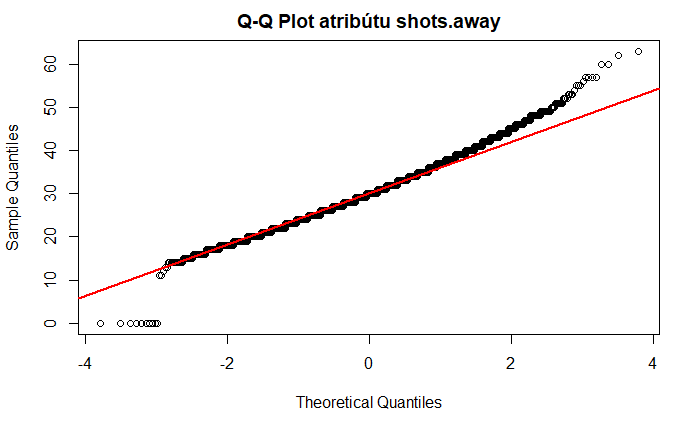

```r
qqnorm(df$shots.away, main="Q-Q Plot atribútu shots.away")
qqline(df$shots.away, col = "red", lwd = 2)
```

Pri QQ-plote atribútu **shots.away** vieme poznamenať v podstate to isté ako pri atribúte **shots.home**. Rozdielom však je pomerne prudšie vychýlenie od teoretickej krivky normálneho rozdelenia pre pri počte striel väčšom rovnom ako 40. Výrazne vychýlená hodnota ako v predošlom grafe tu však nie je, všetky nadobúdajú hodnoty okolo 60 (bolo viditeľné už z krabicového grafu). Vyzerá to však tak, že distribúcia normálna nebude a bude potrebná normalizácia atribútu tak, aby sme normálne rozdelenie dosiahli.

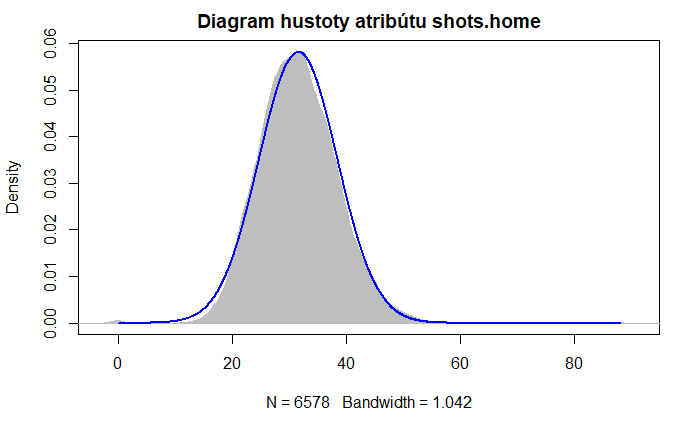

```r
plotNormalDensity(df$shots.home, main = "Diagram hustoty atribútu shots.home")
```